# SharkNinja Robot Amazon 1000 Reviews - NLP

@CicilyWu

[figure not shown]

This NLP project contains 6 parts:

1. **Problem Statement**: State the problems and the objectives of my research.
2. **Data Description**: An introduction of my dataset.
3. **Exploratory Data Analysis (EDA)**: Data cleaning, pre-processing and some basic visualizations.
4. **Topic Modeling (LDA, TFIDF)**: Check the frequencies of each word and set different topic numbers to explore how it works.Topic themes guesses based on top words.Word Cloud Visualizaiton.
5. **Machine Learning Model Prediction**: Only use Logistic Regression and Decision Tree models to perform a quick prediciton on customers'attitudes toward product. I want to focus on NLP in this project so check my other projects if you want to see more ML models usage.
6. **Automatically Summarize Reviews**: A quick way to read long reviews. </font>

# 1. Problem Statement

This is a Natural language processing (NLP) project to analyze 1000 comments made on Amazon about SharkNinja's Shark IQ Robot.I worked on this project right before I joined the company as a full-time exployee as I am interested to learn more about SharkNinja's product. A short explanation about Shark IQ Robt is as below.

The Shark IQ Robot Vacuum combines convenience with intelligence and performance. After each cleaning session, your robot vacuum automatically empties the dust bin into the bag less base, which holds dirt and debris from up to 30 cleaning sessions. With IQ NAV, your robot now maps your whole home, allowing you to select which rooms to clean with Shark Clean App or Alexa. The Shark IQ Robot cleans row by row to assure total floor cleaning. On low battery, your robot recharges and resumes where it left off. And with Shark powerful suction and a self-cleaning brush roll, you get amazing cleaning performance.https://www.amazon.com/Shark-R1001AE-Self-Empty-Connected-Capacity/dp/B07S864GPW

Customers' reviews are always valuable for company to learn customers' habits and improve their products. With only limited numbers from ratings, votes and comments, it is eager to dig more useful information from review texts. Let's start exploration!

# 2. Data Description

I used "Instant Data Scraper" to scrape the most recent reviews on Amazon. This is a useful tool to scape the data and text online and we just need to locate the "Next" button.  
There are lots of useless columns after scraping and the names are messy. After looking into the data I only kept certain columns those might me helpful.

The data contains the following fields:

1. CustomerName: Self-explanatory.
2. Rating: Ratings on Amazon with the full mark 5.
3. ReviewTitle: Self-explanatory.
4. ReviewTime: The time the customers made the review.
5. Review: Review body.
6. HelpfulNumber: Number of votes under the review.
7. ReviewCommentNumber: Number of comments under the review.</font>

# 3. Exploratory Data Analysis (EDA)

Import the libraries first.

```python
import random
random.seed(17)
import pandas as pd
import numpy as np
import datetime
from PIL import *
import PIL.Image
from wordcloud import WordCloud, STOPWORDS, ImageColorGenerator
import seaborn as sns
from collections import Counter
import re
from sklearn.feature_extraction.text import CountVectorizer
from sklearn.feature_extraction.text import TfidfVectorizer
from nltk.corpus import stopwords
from nltk.tokenize import word_tokenize
from nltk.stem import WordNetLemmatizer
from nltk.corpus import wordnet
import string
import nltk
import matplotlib.pyplot as plt
pd.set_option("display.max_colwidth", 200)
import spacy
import gensim
from gensim import corpora
!pip install pyLDAvis
import pyLDAvis
import pyLDAvis.gensim
%matplotlib inline
import inflect
import itertools
nltk.download('stopwords')
nltk.download('punkt')
nltk.download('wordnet')
nltk.download('averaged_perceptron_tagger')
```

```
True
```

Read the data and keep useful columns.

```python
review_all=pd.read_csv('D:\shark_work\shark1000comments.csv')
review_all=review_all.drop(['a-profile href', 'a-profile-avatar','a-link-normal href', 'a-link-normal href 2','a-size-base href 2', 'a-link-normal href 3',
                           'a-link-normal href 4', 'a-lazy-loaded src', 'a-declarative','a-size-base 6','a-size-base 7','a-size-base 5'], axis=1)
#Two ways to change column name:
#df.columns = ['A','B']
#df.rename(columns={'a':'A'})
review_all.columns=['CustomerName','Rating','ReviewTitle','ReviewTime','Verified','Review','HelpfulNumber','ReviewCommentNumber']
review_all.head()
```

|  | CustomerName | Rating | ReviewTitle | ReviewTime | Verified | Review | HelpfulNumber | ReviewCommentNumber |
| --- | --- | --- | --- | --- | --- | --- | --- | --- |
| 0 | B. Mindful | 1.0 out of 5 stars | This is a poor man's Roomba i7+ | Reviewed in the United States on October 10, 2019 | Verified Purchase | I have a Roomba i7+ and bought the Shark IQ R101 for my mother's house hoping that it would perform as good or close to the Roomba i7+. At half the price of the Roomba, I thought it was worth tryi... | 1,031 people found this helpful | 28 |
| 1 | Scott Flack | 3.0 out of 5 stars | The Shark IQ is dim witted. | Reviewed in the United States on October 16, 2019 | Verified Purchase | I had a cheap random motion vacuum robot that worked pretty well. I decided to upgrade to this Shark unit for the added mapping functionality and auto empty. In some ways the cheap off brand uni... | 288 people found this helpful | 7 |
| 2 | RDouglas | 1.0 out of 5 stars | So far so bad but improving | Reviewed in the United States on October 18, 2019 | Verified Purchase | Final update:I made the mistake of saying that it doesn't get stuck in my last review and sure enough the same day it started getting stuck every run. it gets to the stairs or the transition betw... | 282 people found this helpful | 6 |
| 3 | Wesley | 3.0 out of 5 stars | Too aggressive. | Reviewed in the United States on October 21, 2019 | Verified Purchase | I have a roomba 980 that has been working well for my family for about 1.5 years. We wanted a second robot vacuum and decided to give this Shark IQ 101AE a shot given the price point and feature... | 229 people found this helpful | 3 |
| 4 | Bill S. | 1.0 out of 5 stars | Parting Company | Reviewed in the United States on October 22, 2019 | Verified Purchase | I purchased the Shark IQ to replace a NEATO that finally, after many years and cycles of service, went to that robot vacuum cleaner home in the sky. The Shark had some big shoes to fill, but I wa... | 180 people found this helpful | 3 |

```python
Ratings=review_all['Rating'].str.rsplit('.', expand=True, n=1)
del Ratings[1]
review_all = pd.concat([review_all,Ratings], axis=1, join_axes=[review_all.index])
review_all.columns=['CustomerName','Rating','ReviewTitle','ReviewTime','Verified','Review','HelpfulNumber','ReviewCommentNumber','Ratings']
review_all.head()
```

|  | CustomerName | Rating | ReviewTitle | ReviewTime | Verified | Review | HelpfulNumber | ReviewCommentNumber | Ratings |
| --- | --- | --- | --- | --- | --- | --- | --- | --- | --- |
| 0 | B. Mindful | 1.0 out of 5 stars | This is a poor man's Roomba i7+ | Reviewed in the United States on October 10, 2019 | Verified Purchase | I have a Roomba i7+ and bought the Shark IQ R101 for my mother's house hoping that it would perform as good or close to the Roomba i7+. At half the price of the Roomba, I thought it was worth tryi... | 1,031 people found this helpful | 28 | 1 |
| 1 | Scott Flack | 3.0 out of 5 stars | The Shark IQ is dim witted. | Reviewed in the United States on October 16, 2019 | Verified Purchase | I had a cheap random motion vacuum robot that worked pretty well. I decided to upgrade to this Shark unit for the added mapping functionality and auto empty. In some ways the cheap off brand uni... | 288 people found this helpful | 7 | 3 |
| 2 | RDouglas | 1.0 out of 5 stars | So far so bad but improving | Reviewed in the United States on October 18, 2019 | Verified Purchase | Final update:I made the mistake of saying that it doesn't get stuck in my last review and sure enough the same day it started getting stuck every run. it gets to the stairs or the transition betw... | 282 people found this helpful | 6 | 1 |
| 3 | Wesley | 3.0 out of 5 stars | Too aggressive. | Reviewed in the United States on October 21, 2019 | Verified Purchase | I have a roomba 980 that has been working well for my family for about 1.5 years. We wanted a second robot vacuum and decided to give this Shark IQ 101AE a shot given the price point and feature... | 229 people found this helpful | 3 | 3 |
| 4 | Bill S. | 1.0 out of 5 stars | Parting Company | Reviewed in the United States on October 22, 2019 | Verified Purchase | I purchased the Shark IQ to replace a NEATO that finally, after many years and cycles of service, went to that robot vacuum cleaner home in the sky. The Shark had some big shoes to fill, but I wa... | 180 people found this helpful | 3 | 1 |

```python
review_all['HelpfulNumber'].replace('Report abuse',0,inplace=True)
review_all['HelpfulNumber'].replace('One person found this helpful',1,inplace=True)
```

```python
Time=review_all['ReviewTime'].str.rsplit(' ', expand=True, n=3)
#Time['Date'] = Time[1]+' '+Time[2]+' '+Time[3]
Time[1].replace('January',"01",inplace=True)
Time[1].replace('February',"02",inplace=True)
Time[1].replace('March',"03",inplace=True)
Time[1].replace('April',"04",inplace=True)
Time[1].replace('May',"05",inplace=True)
Time[1].replace('June',"06",inplace=True)
Time[1].replace('July',"07",inplace=True)
Time[1].replace('August',"08",inplace=True)
Time[1].replace('September',"09",inplace=True)
Time[1].replace('October',10,inplace=True)
Time[1].replace('November',11,inplace=True)
Time[1].replace('December',12,inplace=True)
Time[2] = Time[2] .map(lambda x: str(x)[:-1])#Delete the last str。Delete the first two str：data['result'] = data['result'].map(lambda x: str(x)[2:])
```

```python
pd.set_option('display.width', 20, 'display.max_rows', 1500)
TimeDays=Time[2]
```

```python
TimeDays=Time[2]
for i in range(0,Time.shape[0]):
    if len(Time[2][i])>1:
        TimeDays[i]=Time[2][i]
    else:
        TimeDays[i]="0"+Time[2][i]
    i += 1

Time['TimeDays']=TimeDays
```

```python
Time[1]= Time[1].apply(str)
Time[2]= Time[2].apply(str)
Time[3]= Time[3].apply(str)
Time['TimeDays']= Time['TimeDays'].apply(str)
```

```python
Time['Date']=Time[3]+'-'+Time[1]+'-'+Time['TimeDays']
Time.head()
```

|  | 0 | 1 | 2 | 3 | TimeDays | Date |
| --- | --- | --- | --- | --- | --- | --- |
| 0 | Reviewed in the United States on | 10 | 10 | 2019 | 10 | 2019-10-10 |
| 1 | Reviewed in the United States on | 10 | 16 | 2019 | 16 | 2019-10-16 |
| 2 | Reviewed in the United States on | 10 | 18 | 2019 | 18 | 2019-10-18 |
| 3 | Reviewed in the United States on | 10 | 21 | 2019 | 21 | 2019-10-21 |
| 4 | Reviewed in the United States on | 10 | 22 | 2019 | 22 | 2019-10-22 |

```python
Time['Date'] = pd.to_datetime(Time['Date'])
del Time[0]
Time.columns=['ReviewMonth','ReviewDate','ReviewYear','TimeDays','Date']
```

```python
review_all = pd.concat([review_all,Time], axis=1, join_axes=[review_all.index])
```

```python
review_all.drop(['Rating','ReviewTime','ReviewDate','TimeDays'], axis=1, inplace=True)
```

```python
#review_all['Ratings'].to_numeric(review_all, errors='ignore')
review_all['Ratings'] =review_all['Ratings'].apply(pd.to_numeric)
```

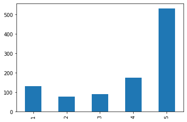

```python
review_all['Ratings'].value_counts().sort_index().plot(kind='bar')
```

More than 500 reviews got 5 stars! Also almost 200 reviews got 4 stars. Excellent job Shark Robot!

```python
review_all['HelpfulNumber'].replace(regex=True,inplace=True,to_replace=r'\D',value=r'') #only keep numbers
review_all['HelpfulNumber'].replace('',"0",inplace=True)
review_all['HelpfulNumber'] = review_all['HelpfulNumber'].astype('int')
votes=review_all.groupby('Ratings').HelpfulNumber.sum()
votes=votes.to_frame()
```

```python
review_all['ReviewCommentNumber'].replace('',"0",inplace=True)
review_all['ReviewCommentNumber'] = review_all['ReviewCommentNumber'].astype('int')
comments_num=review_all.groupby('Ratings').ReviewCommentNumber.sum()
comments_num=comments_num.to_frame()
```

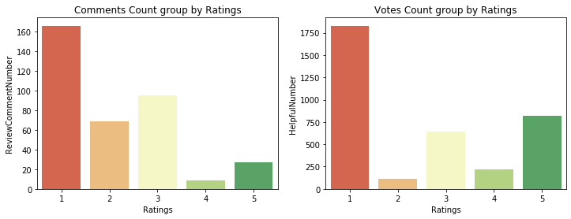

```python
axes=plt.figure(figsize=(12,4))

plt.subplot(121)
ax1=sns.barplot(x=comments_num.index, y ='ReviewCommentNumber',data=comments_num,palette="RdYlGn")#axa 小图在大图中的位置
ax1.set_title('Comments Count group by Ratings')

plt.subplot(122)
ax2=sns.barplot(x=votes.index, y ='HelpfulNumber',data=votes,palette="RdYlGn")#axa 小图在大图中的位置
ax2.set_title('Votes Count group by Ratings')
```

Above two plots are showing the total number of comments and votes received by each Ratings. 1-star reviews received most votes and comments, which means people are more focused on "negative reviews" when doing the research. Reviews with highest votes are most likely to be shown on the top based on Amazon's algorithm (from my observation). One of the best marketing strategies is to gain more votes on 5-star reviews so that customers can see more "positive reviews" when they make buying decisions. Also, higher comments under reviews means the 1-start reviews received more attention. As many customers may glance over comments under 1-star reviews, the customer service from SN's better to present appropriate solutions to help customers fix the issues or provide convincing explanation in the comments.

Now start the word processing by deleting the stop words,lowercasing all words and tokenizing the reviews. Also, we count the original number counts and words count after cleaning.

```python
# words to be removed from vocabulary
blockwords = ['a', 'about', 'above', 'after', 'again', 'against', 'all', 'am', 'an', 'and', 'any', 'are', "aren't", 'as', 'at','since','paid','don','doesn','close',
 'be', 'because', 'been', 'before', 'being', 'below', 'between', 'both', 'but', 'by', 'doing', "don't", 'down', 'during',
 'each', 'few', 'for', 'from', 'further', 'had', "hadn't", 'has', "hasn't", 'have', "haven't", 'having', 'he', "he'd", "he'll", "he's", 'her', 'here', "here's",
 'hers', 'herself', 'him', 'himself', 'his', 'how', "how's", 'i', "i'd", "i'll", "i'm", "i've", 'if', 'in', 'into', 'is', "isn't", 'it', "it's", 'its', 'itself',
 "let's", 'me', 'more', 'most', "mustn't", 'my', 'myself', 'of', 'off', 'on', 'once', 'only', 'or', 'other', 'ought', 'our', 'ours' 'ourselves', 'out', 'over', 'own',
 'same', "shan't", 'she', "she'd", "she'll", "she's", 'should', "shouldn't", 'so', 'some', 'such', 'like',
 'than', 'that',"that's", 'the', 'their', 'theirs', 'them', 'themselves', 'then', 'there', "there's", 'these', 'they', "they'd", 'also','can','could','should',
 "they'll", "they're", "they've", 'this', 'those', 'through', 'to', 'too', 'under', 'until', 'up', 'very', 'not','bit','much',
 'was', "wasn't", 'we', "we'd", "we'll", "we're", "we've", 'were', "weren't", 'what', "what's", 'when', "when's", 'where','within','quite','really','just','together',
 "where's", 'which', 'while', 'who', "who's", 'whom', 'why', "why's",'will', 'with', "won't", 'would', "wouldn't", 'hole','furniture','put',
 'you', "you'd", "you'll", "you're", "you've", 'your', 'yours', "s'yourself'", 'yourselves', 'drawer','sure',
 'one', 'two', 'three', 'four', 'five', 'six', 'seven', 'eight', 'nine', 'ten', 'hundred', 'thousand', '1st', '2nd', '3rd','nightstand','nightstands','night',
 '4th', '5th', '6th', '7th', '8th', '9th', '10th']
```

```python
review_all['Review']= review_all['Review'].apply(str)
```

```python
stop_words = set(stopwords.words('english'))                      # set of all stop words
lem=WordNetLemmatizer()
p=inflect.engine()

def process(comment):
  sent = comment.lower()                                          # lower case all words
  words = nltk.word_tokenize(sent)
  words =  [word for word in words if not word in blockwords]     # remove words present in blockwords
  words = [word for word in words if not word.isdigit()]          # remove digit characters
  words = [word for word in words if len(word) > 3]               # remove words with length less than 3
  words = [word for word in words if word.isalpha()]              # remove non alphabetic words
  words = [lem.lemmatize(word) for word in words]                 # lemmatize words to root word
  sent = ' '.join(words)
  sent = re.sub(r'\(', '', sent)
  sent = re.sub(r'\)', '', sent)
  sent = re.sub(r"'", '', sent)
  return sent

def num_words(sent):                                              # returns number of words in the sentence
  word_tok=nltk.word_tokenize(sent)
  return len(word_tok)

review_all['Cleaned_Comment']=review_all['Review'].apply(process)
review_all['Unclean_len']=review_all['Review'].apply(num_words)                     # word length of uncleaned comments
review_all['Clean_len']=review_all.Cleaned_Comment.apply(num_words)               # word length of cleaned comments
review_all['percentage reduction']=(review_all['Unclean_len']-review_all['Clean_len'])/review_all['Unclean_len']*100 # percentage of reduction
```

```python
five_rated=review_all[review_all['Ratings']==5] #filter the dataframe by rating=5
text= " ".join(five_rated['Cleaned_Comment'])
```

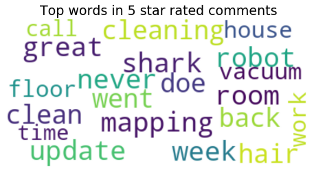

```python
# Display the generated image:
wordcloud = WordCloud(max_font_size=35, max_words=40, background_color="white",collocations=False).generate(text)
plt.figure(figsize=(8,6))
plt.imshow(wordcloud, interpolation="gaussian")
plt.title('Top words in 5 star rated comments',size=19)
plt.axis("off")
plt.show()
```

Most popular words showing in 5 star reviews are showing in the word cloud. We can see that mapping function,cleaning hair well and ability to work on a schedule mean a lot to customers!

# 4. Topic Modeling (LDA, TFIDF)

```python
comments=[]
for i in range(review_all.shape[0]):
  comments.append(review_all['Cleaned_Comment'].apply(nltk.word_tokenize).values[i])  # tokenize all the words in all the comments
```

```python
num_topics = 3 # number of topics

dictionary = corpora.Dictionary(comments) # create a dictionary of all words
doc_term_matrix = [dictionary.doc2bow(rev) for rev in comments]

LDA = gensim.models.ldamodel.LdaModel
# Build LDA model
lda_model = LDA(corpus=doc_term_matrix, id2word=dictionary, num_topics=num_topics, random_state=100,chunksize=1000, passes=50)
```

```python
lda_model.print_topics() # 3 topics have been generated along with the importance of each word in the topic
```

```
[(0,
  '0.030*"vacuum" + 0.025*"shark" + 0.020*"house" + 0.018*"hair" + 0.018*"week" + 0.015*"never" + 0.015*"floor" + 0.015*"cleaning" + 0.011*"great" + 0.010*"went"'),
 (1,
  '0.035*"time" + 0.032*"room" + 0.023*"clean" + 0.019*"doe" + 0.019*"vacuum" + 0.016*"back" + 0.012*"call" + 0.012*"update" + 0.012*"work" + 0.012*"mapping"'),
 (2,
  '0.017*"vacuum" + 0.014*"clean" + 0.014*"robot" + 0.012*"shark" + 0.012*"doe" + 0.011*"time" + 0.010*"floor" + 0.009*"house" + 0.009*"great" + 0.009*"work"')]
```

I intend to separate the texts into 3 topics at first. The 3 groups and corresponding critical words as well as the determination probability is shown. I don't think we can get enough information from these 3 groups, which means 3 topics may not enough. I'll explore setting more groups later. But from this result, we can basically guess in this situation, the first group focuses on how great the robot can clean the house floor and never got stuckso far; the second group focuses on that the robots can follow a schedule to clean the house and the third group is basically the same as the first one.

```python
topic_words=[]
for i in range(num_topics):
  for j in range(25):
    try:
        topic_words.append(lda_model.print_topic(topicno=i).split('+')[j].split('"')[1]) # get all topic words
    except:
      pass
```

```python
topic_words
```

```
['vacuum',
 'shark',
 'house',
 'hair',
 'week',
 'never',
 'floor',
 'cleaning',
 'great',
 'went',
 'time',
 'room',
 'clean',
 'doe',
 'vacuum',
 'back',
 'call',
 'update',
 'work',
 'mapping',
 'vacuum',
 'clean',
 'robot',
 'shark',
 'doe',
 'time',
 'floor',
 'house',
 'great',
 'work']
```

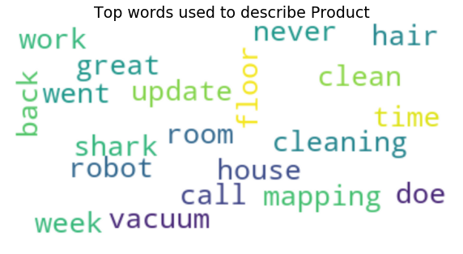

```python
topic_words=list(set(topic_words)) #set() got a no-sequence no-repeat set
text= " ".join(topic_words)
# Display the generated image:
wordcloud = WordCloud(max_font_size=25, max_words=len(topic_words), background_color="white",collocations=False).generate(text)
plt.figure(figsize=(10,8))
plt.imshow(wordcloud, interpolation="gaussian")
plt.title('Top words used to describe Product',size=19)
plt.axis("off")
plt.show()
```

```python
pyLDAvis.enable_notebook()
vis = pyLDAvis.gensim.prepare(lda_model, doc_term_matrix, dictionary)
vis
```

[interactive chart not shown]

This step is to devide them based on their attitude towards products to perform sentiment analysis later. I set rating 1-3 as Negative, rating 4 as Neutral and rating 5 as Positive. This may sound supr strict at first impression but from what I know, SharkNinja's been keeping thier product review star as 4.3+ in total, which shows this critiria is not hard to meet for SharkNinja Robot Team.

```python
review_all['attitude']=review_all['Ratings']
review_all['attitude'].replace(1,'Negative',inplace=True)
review_all['attitude'].replace(2,'Negative',inplace=True)
review_all['attitude'].replace(3,'Negative',inplace=True)
review_all['attitude'].replace(4,'Neutral',inplace=True)
review_all['attitude'].replace(5,'Positive',inplace=True)

review_all.head()
```

|  | CustomerName | ReviewTitle | Verified | Review | HelpfulNumber | ReviewCommentNumber | Ratings | ReviewMonth | ReviewYear | Date | Cleaned_Comment | Unclean_len | Clean_len | percentage reduction | attitude |
| --- | --- | --- | --- | --- | --- | --- | --- | --- | --- | --- | --- | --- | --- | --- | --- |
| 0 | B. Mindful | This is a poor man's Roomba i7+ | Verified Purchase | I have a Roomba i7+ and bought the Shark IQ R101 for my mother's house hoping that it would perform as good or close to the Roomba i7+. At half the price of the Roomba, I thought it was worth tryi... | 1,031 people found this helpful | 28 | 1 | 10 | 2019 | 2019-10-10 | roomba bought shark mother house hoping perform good roomba half price roomba thought worth trying well shark basically poor roomba look even make little jingle roomba self disposing empty term pe... | 419 | 129 | 69.212411 | Negative |
| 1 | Scott Flack | The Shark IQ is dim witted. | Verified Purchase | I had a cheap random motion vacuum robot that worked pretty well. I decided to upgrade to this Shark unit for the added mapping functionality and auto empty. In some ways the cheap off brand uni... | 288 people found this helpful | 7 | 3 | 10 | 2019 | 2019-10-16 | cheap random motion vacuum robot worked pretty well decided upgrade shark unit added mapping functionality auto empty way cheap brand unit thing extremely loud want algorithm us seem half baked ge... | 152 | 67 | 55.921053 | Negative |
| 2 | RDouglas | So far so bad but improving | Verified Purchase | Final update:I made the mistake of saying that it doesn't get stuck in my last review and sure enough the same day it started getting stuck every run. it gets to the stairs or the transition betw... | 282 people found this helpful | 6 | 1 | 10 | 2019 | 2019-10-18 | final update made mistake saying doe stuck last review enough started getting stuck every get stair transition different color floor decided cliff sensor blocked wont tried fix manufacturer still ... | 706 | 254 | 64.022663 | Negative |
| 3 | Wesley | Too aggressive. | Verified Purchase | I have a roomba 980 that has been working well for my family for about 1.5 years. We wanted a second robot vacuum and decided to give this Shark IQ 101AE a shot given the price point and feature... | 229 people found this helpful | 3 | 3 | 10 | 2019 | 2019-10-21 | roomba working well family year wanted second robot vacuum decided give shark shot given price point feature list basic design robot self empty look solid problem robot performs roomba slow bump o... | 267 | 130 | 51.310861 | Negative |
| 4 | Bill S. | Parting Company | Verified Purchase | I purchased the Shark IQ to replace a NEATO that finally, after many years and cycles of service, went to that robot vacuum cleaner home in the sky. The Shark had some big shoes to fill, but I wa... | 180 people found this helpful | 3 | 1 | 10 | 2019 | 2019-10-22 | purchased shark replace neato finally many year cycle service went robot vacuum cleaner home shark shoe fill confident advertised feature well task sadly feature important first obviously need cle... | 489 | 165 | 66.257669 | Negative |

```python
review_clean=review_all[['Cleaned_Comment','Attitude']]
```

For TF-IDF, I set maximum number of features of 200 which means only 200 words will show up after processing.I will drop words those show up more than 95% and those appear less than 5 times.

```python
num_features=200
tfidf = TfidfVectorizer(max_df=0.95, min_df=5, max_features=num_features, stop_words='english')
X_tf =tfidf.fit_transform(review_clean['Cleaned_Comment'])
print('The number of features:',X_tf.shape[1])
```

```
The number of features: 200
```

```python
tf_vect_df = pd.DataFrame(X_tf.todense(), columns=tfidf.get_feature_names())
tf=pd.concat([review_clean,tf_vect_df],axis=1)
tf.head(2)
```

|  | Cleaned_Comment | Attitude | ability | able | absolutely | actually | alexa | amazing | amazon | area | ... | wanted | week | went | wifi | wish | work | worked | working | worth | year |
| --- | --- | --- | --- | --- | --- | --- | --- | --- | --- | --- | --- | --- | --- | --- | --- | --- | --- | --- | --- | --- | --- |
| 0 | roomba bought shark mother house hoping perform good roomba half price roomba thought worth trying well shark basically poor roomba look even make little jingle roomba self disposing empty term pe... | Negative | 0.0 | 0.0 | 0.0 | 0.0 | 0.0 | 0.0 | 0.0 | 0.0 | ... | 0.107442 | 0.078375 | 0.0 | 0.0 | 0.0 | 0.000000 | 0.000000 | 0.0 | 0.096401 | 0.0 |
| 1 | cheap random motion vacuum robot worked pretty well decided upgrade shark unit added mapping functionality auto empty way cheap brand unit thing extremely loud want algorithm us seem half baked ge... | Negative | 0.0 | 0.0 | 0.0 | 0.0 | 0.0 | 0.0 | 0.0 | 0.0 | ... | 0.000000 | 0.000000 | 0.0 | 0.0 | 0.0 | 0.117391 | 0.221515 | 0.0 | 0.000000 | 0.0 |

2 rows × 202 columns

DataFrame "tf" above is apparently a sparse matrix and it would be helpful to change it to dense matrix later.

```python
#example of the features
m1 = (tf['Cleaned_Comment'] == tf.iloc[100]['Cleaned_Comment'])
m2 = (tf[m1] != 0).all()
tf.loc[m1,m2]
```

|  | Cleaned_Comment | Attitude | amazing | area | bought | clean | cleaning | cord | didn | doe | ... | review | room | self | send | setting | stuck | twice | unit | wife | work |
| --- | --- | --- | --- | --- | --- | --- | --- | --- | --- | --- | --- | --- | --- | --- | --- | --- | --- | --- | --- | --- | --- |
| 100 | bought wife love amazed well doe large dog lot hair imagine setting little wonder hair gone amazing watch work around everything stuck twice fault leaving cord floor soon clearing obstruction almo... | Positive | 0.150289 | 0.247503 | 0.134339 | 0.250889 | 0.097565 | 0.183831 | 0.183831 | 0.088289 | ... | 0.143446 | 0.110024 | 0.123752 | 0.180727 | 0.182248 | 0.119222 | 0.170325 | 0.148951 | 0.381802 | 0.090263 |

1 rows × 31 columns

```python
def Convert(tup): # convert list of tuple to dictionary
    di = dict(tup)
    return di
```

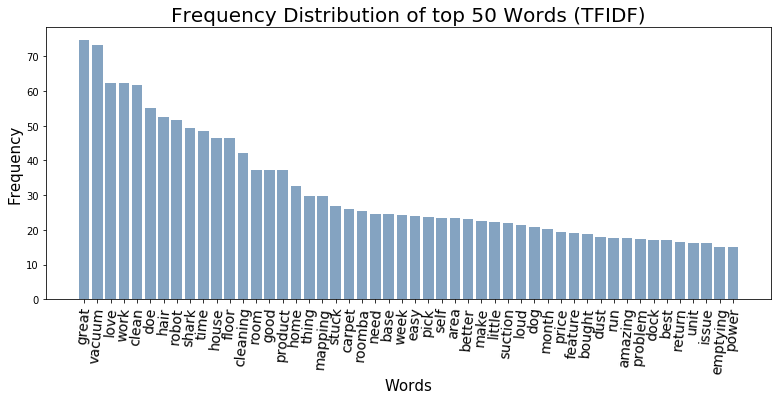

```python
sum_words_tf = X_tf.sum(axis=0)
words_freq_tf = [(word, sum_words_tf[0, idx]) for word, idx in tfidf.vocabulary_.items()]
words_freq_tf =sorted(words_freq_tf, key = lambda x: x[1], reverse=True) # list of tuples in order

words_frequency_tf=Convert(words_freq_tf)
top_50_tf=dict(Counter(words_frequency_tf).most_common(50))

plt.figure(figsize=(13,5))
plt.title('Frequency Distribution of top 50 Words (TFIDF)',size=20)
plt.ylabel('Frequency',size=15)
plt.xlabel('Words',size=15)
plt.xticks(rotation=85,size=14)
plt.bar(top_50_tf.keys(),top_50_tf.values(),color=(0.2, 0.4, 0.6, 0.6))
plt.gca().xaxis.grid(False)
plt.show()
```

Above is the word-frequency chart based on TF-IDF. As we can see that 2 of top 3 words are very positive words as "great" and "love". "Clean" was also been mentioned many times which means robots are really doing a great job! It is interesting to see that "roomba"'s also showing up in this list. As iRobot is one of strong competitors for SharkNinja, it makes sense that customers are making comparison between their products.

Now let's keep going on "Topic Modeling" journey that I want to see what will happen if we change the topic numbers. Are we able to tell a topic theme based on the results?

```python
from sklearn.model_selection import train_test_split
from sklearn.preprocessing import MinMaxScaler
from sklearn.decomposition import LatentDirichletAllocation,TruncatedSVD
from sklearn.cluster import KMeans
from sklearn.preprocessing import MinMaxScaler
from sklearn.manifold import TSNE

from sklearn.linear_model import LogisticRegression
from sklearn.naive_bayes import MultinomialNB
from sklearn.svm import LinearSVC
from sklearn.model_selection import train_test_split
from sklearn.model_selection import cross_val_score
from sklearn.ensemble import VotingClassifier

from nltk.stem.snowball import SnowballStemmer
from nltk.tokenize import RegexpTokenizer
#x_train, x_test, y_train, y_test = train_test_split(tfidf, review_all['Cleaned_Comment'], test_size=0.2)
```

```python
def display_topics(model, feature_names, num_top_words):
  topics=dict()
  for topic_idx, topic in enumerate(model.components_):
    topics[topic_idx]=" ".join([feature_names[i] for i in topic.argsort()[:-num_top_words - 1:-1]])
  return topics
```

```python
num_top_words = 50
num_topics=6

X_tf_feature_names =tfidf.get_feature_names()
lda = LatentDirichletAllocation(n_components=num_topics, max_iter=5, learning_method='online', learning_offset=50.,random_state=0).fit(X_tf)
topic_tf=display_topics(lda, X_tf_feature_names, num_top_words)
X_tf_topics = lda.transform(X_tf)
```

```python
topic_names=['Topic '+str(i) for i in range(0,6)]

df_topics=pd.DataFrame.from_records(X_tf_topics)#DataFrame.from_records接受字典列表并创建一个数据框，该字典的每个键都有一列。
df_topics.columns=topic_names
topics=pd.concat([review_clean,df_topics],axis=1)
topics.head(2)
```

[output not shown]

```python
topics.loc[10]
```

```
Cleaned_Comment    always wanted smart robot vacuum price always scared shark offer affordable price decided give shot pet house found useful clean hair work great hard floor carpet issue transitioning controlled mo...
attitude                                                                                                                                                                                                          Positive
Topic 0                                                                                                                                                                                                          0.0246969
Topic 1                                                                                                                                                                                                          0.0246922
Topic 2                                                                                                                                                                                                          0.0248318
Topic 3                                                                                                                                                                                                          0.0250922
Topic 4                                                                                                                                                                                                           0.875943
Topic 5                                                                                                                                                                                                          0.0247436
Name: 10, dtype: object
```

Above, take 11th review as an example, there is 87.5% that it will drop into the 5th topic.

```python
# Define helper function to print top words
def print_top_words(model, feature_names, n_top_words):
    for index, topic in enumerate(model.components_):
        message = "\nTopic #{}:".format(index)
        message += " ".join([feature_names[i] for i in topic.argsort()[:-n_top_words - 1 :-1]])
        print(message)
        print("="*70)
```

```python
n_top_words = 10
print("\nTopics in LDA model: ")
tf_feature_names = tfidf.get_feature_names()
print_top_words(lda, tf_feature_names, n_top_words)
```

```
Topics in LDA model:

Topic #0:stuck christmas foot finish sensor used station getting base thing
======================================================================

Topic #1:support suck called tried connect time help wifi hair room
======================================================================

Topic #2:connect remote perfect compared software robot debris unit properly start
======================================================================

Topic #3:love clean vacuum room robot doe house time shark cleaning
======================================================================

Topic #4:great work vacuum hair product love doe floor shark easy
======================================================================

Topic #5:item review pattern error time phone life tried returned doe
======================================================================
```

Above are the top words in 6 topics. Let's take a guess on the themes of these topics based on important workds.

Topic0: With "stuck" as the top 1 word, I assume this topic contains mostly netative reviews and basically blaming on because of "sensor" and other problems showing up, the robots are always get "stuck" and not able to "finish" the whole cleaning process.

Topic1: Suck has the big power and wifi got connected pretty well.

Topic2: Because of good connection between the mobile and robot, remote control works smoothly.

Topic3: Just love this!

Topic4: It works great just love it! I guess this one is similar to the last topic.

Topic5: This topic contains few negative words like "error" and "returned" which may be saying that they have to return the robot because of many errors.</font>

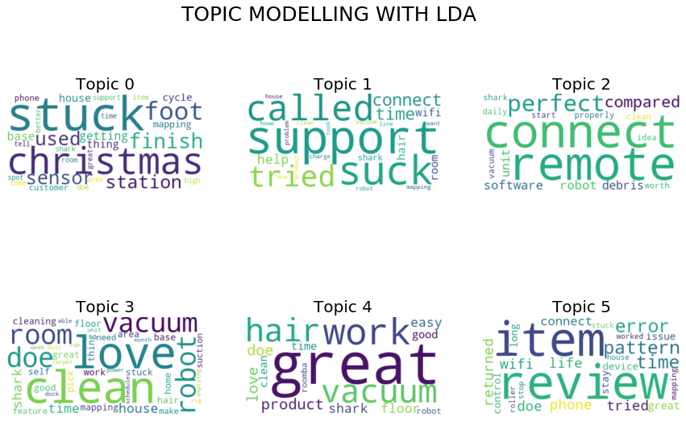

```python
# word cloud to represent top words in each news topic
f,axes=plt.subplots(2,3,sharex=False,sharey=False,figsize=(45, 8))
ax = axes.ravel()
for i in range(0,6):
  wordcloud = WordCloud(background_color='white',min_font_size=12).generate(topic_tf[i])
  ax[i].imshow(wordcloud, interpolation="bilinear")
  ax[i].axis("off")
  ax[i].set_title('Topic '+str(i),size=20)
  ax[i].margins(x=0, y=0)
f.set_figheight(9)
f.set_figwidth(15)
f.suptitle('TOPIC MODELLING WITH LDA ',size=25)
plt.subplots_adjust(hspace=0.3)
plt.subplots_adjust(wspace=0.2)
plt.show()
```

Reduce number to 5

```python
num_top_words = 50
num_topics=5
X_tf_feature_names =tfidf.get_feature_names()
lda = LatentDirichletAllocation(n_components=num_topics, max_iter=10, learning_method='online', learning_offset=50.,random_state=0).fit(X_tf)#X_bow_1
topic_tf=display_topics(lda, X_tf_feature_names, num_top_words)
```

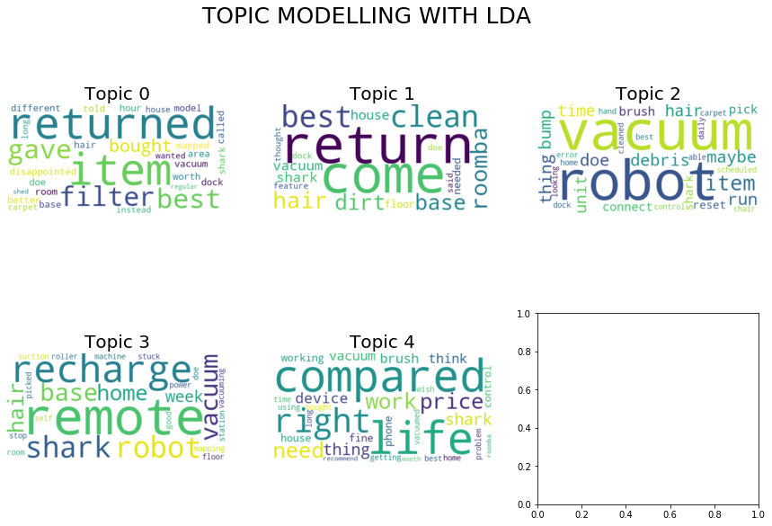

```python
f,axes=plt.subplots(2,3,sharex=False,sharey=False,figsize=(45, 8))
ax = axes.ravel()
for i in range(0,5):
  wordcloud = WordCloud(background_color='white',min_font_size=12).generate(topic_tf[i])
  ax[i].imshow(wordcloud, interpolation="bilinear")
  ax[i].axis("off")
  ax[i].set_title('Topic '+str(i),size=20)
  ax[i].margins(x=0, y=0)
f.set_figheight(9)
f.set_figwidth(15)
f.suptitle('TOPIC MODELLING WITH LDA ',size=25)
plt.subplots_adjust(hspace=0.3)
plt.subplots_adjust(wspace=0.2)
plt.show()
```

Expand topics number to 10

```python
num_top_words = 30
num_topics=10
X_tf_feature_names =tfidf.get_feature_names()
lda = LatentDirichletAllocation(n_components=num_topics, max_iter=10, learning_method='online', learning_offset=50.,random_state=0).fit(X_tf)#X_bow_1
topic_tf=display_topics(lda, X_tf_feature_names, num_top_words)
```

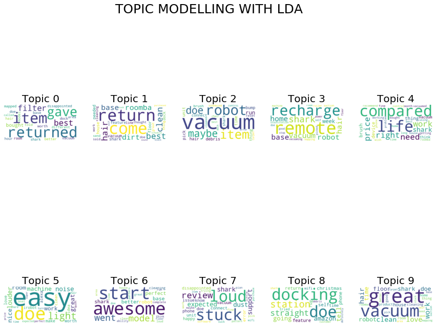

```python
f,axes=plt.subplots(2,5,sharex=False,sharey=False,figsize=(45, 6))
ax = axes.ravel()
for i in range(0,10):
  wordcloud = WordCloud(background_color='white',min_font_size=12).generate(topic_tf[i])
  ax[i].imshow(wordcloud, interpolation="bilinear")
  ax[i].axis("off")
  ax[i].set_title('Topic '+str(i),size=20)
  ax[i].margins(x=0, y=0)
f.set_figheight(12)
f.set_figwidth(15)
f.suptitle('TOPIC MODELLING WITH LDA ',size=25)
#plt.subplots_adjust(hspace=0.3)
#plt.subplots_adjust(wspace=0.2)
plt.show()
```

I also changed the topic numbers to 5 and 10 to check the changes. The visualization result is shown as above.

# 5. Machine Learning Model Prediction

I want to be able to predict the emotions a customer towards the robot based on their reviews. I only chose Logistic Regression and Decision Tree models for this prediction since I've been explored a lot of details about different machine learning models in other projects and the whole point of this project is NLP.

```python
tf1=tf.drop(['Cleaned_Comment'], axis=1)
```

```python
tf1['Attitude'].unique()
```

```
array(['Negative', 'Positive', 'Neutral'], dtype=object)
```

The target variable is "Attitude" obviously. To transfer them into numerical data, I set 0,1,2 for three attitudes correspondingly.

```python
tf1['Attitude'].replace('Negative',0,inplace=True)
tf1['Attitude'].replace('Neutral',1,inplace=True)
tf1['Attitude'].replace('Positive',2,inplace=True)
tf1.head()
```

|  | Attitude | ability | able | absolutely | actually | alexa | amazing | amazon | area | away | ... | wanted | week | went | wifi | wish | work | worked | working | worth | year |
| --- | --- | --- | --- | --- | --- | --- | --- | --- | --- | --- | --- | --- | --- | --- | --- | --- | --- | --- | --- | --- | --- |
| 0 | 0 | 0.000000 | 0.000000 | 0.0 | 0.00000 | 0.0 | 0.0 | 0.00000 | 0.000000 | 0.0 | ... | 0.107442 | 0.078375 | 0.000000 | 0.000000 | 0.0 | 0.000000 | 0.000000 | 0.000000 | 0.096401 | 0.000000 |
| 1 | 0 | 0.000000 | 0.000000 | 0.0 | 0.00000 | 0.0 | 0.0 | 0.00000 | 0.000000 | 0.0 | ... | 0.000000 | 0.000000 | 0.000000 | 0.000000 | 0.0 | 0.117391 | 0.221515 | 0.000000 | 0.000000 | 0.000000 |
| 2 | 0 | 0.074237 | 0.119778 | 0.0 | 0.07044 | 0.0 | 0.0 | 0.07619 | 0.152500 | 0.0 | ... | 0.000000 | 0.000000 | 0.000000 | 0.000000 | 0.0 | 0.148309 | 0.000000 | 0.000000 | 0.000000 | 0.000000 |
| 3 | 0 | 0.000000 | 0.000000 | 0.0 | 0.00000 | 0.0 | 0.0 | 0.00000 | 0.000000 | 0.0 | ... | 0.090691 | 0.000000 | 0.000000 | 0.000000 | 0.0 | 0.000000 | 0.000000 | 0.083643 | 0.000000 | 0.086644 |
| 4 | 0 | 0.133476 | 0.000000 | 0.0 | 0.00000 | 0.0 | 0.0 | 0.00000 | 0.091397 | 0.0 | ... | 0.000000 | 0.000000 | 0.128438 | 0.131353 | 0.0 | 0.000000 | 0.000000 | 0.000000 | 0.000000 | 0.351408 |

5 rows × 201 columns

```python
x_train, x_test, y_train, y_test = train_test_split(tf1, tf1['Attitude'], test_size=0.3)
```

```python
x_train=x_train.drop(['Attitude'], axis=1)
x_test=x_test.drop(['Attitude'], axis=1)
```

```python
print(x_train.shape)
print(x_test.shape)
print(y_train.shape)
print(y_test.shape)
```

```
(707, 200)
(303, 200)
(707,)
(303,)
```

```python
from sklearn.linear_model import LinearRegression, Ridge
from sklearn.ensemble import RandomForestRegressor, GradientBoostingRegressor
from sklearn.svm import SVR
from sklearn.neighbors import KNeighborsRegressor
from sklearn.linear_model import LogisticRegression
from sklearn.naive_bayes import GaussianNB
from sklearn import neighbors
from sklearn.tree import DecisionTreeClassifier
from sklearn.model_selection import cross_val_score
from sklearn.metrics import accuracy_score
```

```python
def model_prediction(algo):
    model = algo
    model.fit(x_train, y_train)
    y_pred = model.predict(x_test)
    acc=accuracy_score(y_test, y_pred)
    #output = pd.DataFrame({'Item_Identifier':test['Item_Identifier'], 'Outlet_Identifier':test['Outlet_Identifier'], 'Item_Outlet_Sales':y_pred}, columns=['Item_Identifier','Outlet_Identifier', 'Item_Outlet_Sales'])
    return acc #, output
```

```python
lr=LogisticRegression()
lr.fit(x_train,y_train)
lr_acc=model_prediction(lr)
lr_acc
```

```
0.6468646864686468
```

```python
from sklearn.tree import DecisionTreeClassifier
dtree = DecisionTreeClassifier()
dtree.fit(x_train,y_train)
dtree_acc = model_prediction(dtree)
dtree_acc
```

```
0.49504950495049505
```

```python
import eli5
from eli5.sklearn import PermutationImportance

perm = PermutationImportance(lr, random_state=1).fit(x_test, y_test)#支持向量机
eli5.show_weights(perm, feature_names = x_test.columns.tolist())
```

| Weight | Feature |
| --- | --- |
| 0.0191 ± 0.0153 | love |
| 0.0185 ± 0.0148 | great |
| 0.0099 ± 0.0125 | amazing |
| 0.0099 ± 0.0042 | robot |
| 0.0066 ± 0.0083 | month |
| 0.0066 ± 0.0000 | didn |
| 0.0066 ± 0.0072 | cleaning |
| 0.0066 ± 0.0093 | loud |
| 0.0053 ± 0.0067 | light |
| 0.0046 ± 0.0090 | dust |
| 0.0046 ± 0.0090 | best |
| 0.0046 ± 0.0053 | floor |
| 0.0040 ± 0.0049 | house |
| 0.0040 ± 0.0049 | noise |
| 0.0040 ± 0.0097 | hair |
| 0.0040 ± 0.0049 | complete |
| 0.0040 ± 0.0097 | room |
| 0.0040 ± 0.0026 | software |
| 0.0040 ± 0.0065 | recommend |
| 0.0040 ± 0.0026 | small |
| *… 180 more …* |  |

The Logistic Regression model reached a 65% accuracy predicting their attitude toward products. I also print top words those affect the result the most.

# 6. Automatically Summarize Reviews

Sometimes customers are super excited that they type a very long review which takes a lot of time to read. I think it should be great if we can have a function that could shorten the long review and summarize it by only showing the important words. Scroll down to the bottom to see how it works.

```python
import en_core_web_sm
nlp = en_core_web_sm.load()
```

```python
import base64
import string
import re
from collections import Counter
from time import time
import heapq
from nltk.corpus import stopwords
import nltk
stopwords = stopwords.words('english')
sns.set_context('notebook')
import spacy
```

```python
!pip install https://github.com/explosion/spacy-models/releases/download/en_core_web_sm-2.2.0/en_core_web_sm-2.2.0.tar.gz
```

```
  Found existing installation: en-core-web-sm 2.2.5
    Uninstalling en-core-web-sm-2.2.5:
      Successfully uninstalled en-core-web-sm-2.2.5
```

```python
def normalize_text(text): # normalize the text by cleaning it and preprocessing it
    tm1 = re.sub('<pre>.*?</pre>', '', text, flags=re.DOTALL)
    tm2 = re.sub('<code>.*?</code>', '', tm1, flags=re.DOTALL)
    tm3 = re.sub('<[^>]+>©', '', tm1, flags=re.DOTALL)
    return tm3.replace("\n", "")
```

```python
punctuations = '!"#$%&\'()*+,-/:;<=>?@[\\]^_`{|}~©'
# Define function to cleanup text by removing personal pronouns, stopwords, and puncuation
def cleanup_text(docs, logging=False):
    texts = []
    doc = nlp(docs, disable=['parser', 'ner'])
    tokens = [tok.lemma_.lower().strip() for tok in doc if tok.lemma_ != '-PRON-']
    tokens = [tok for tok in tokens if tok not in stopwords and tok not in punctuations]
    tokens = ' '.join(tokens)
    texts.append(tokens)
    return pd.Series(texts)
```

```python
review_all['Cleaned']=review_all['Review'].apply(normalize_text)
review_all['normalize'] = review_all['Cleaned'].apply(lambda x: cleanup_text(x, False))
```

```python
print('Before normalizing text-----\n')
print(review_all['Review'][4])
print('\nAfter normalizing text-----\n')
print(review_all['normalize'][4])
```

```
Before normalizing text-----

I purchased the Shark IQ to replace a NEATO that finally, after many years and cycles of service, went to that robot vacuum cleaner home in the sky.  The Shark had some big shoes to fill, but I was confident that, with the advertised features, it was well up to the task.  I was, sadly, disappointed.…

After normalizing text-----

purchase shark iq replace neato finally many year cycle service go robot vacuum clean home sky . shark big shoe fill confident advertise feature well task . sadly disappointed . two feature vac important . first obviously need clean well . black cat leave fur place 14 year old son much well leave va…
```

```python
# this is function for text summarization
def generate_summary(text_without_removing_dot, cleaned_text):
    sample_text = text_without_removing_dot
    doc = nlp(sample_text)
    sentence_list=[]
    for idx, sentence in enumerate(doc.sents): # we are using spacy for sentence tokenization
        sentence_list.append(re.sub(r'[^\w\s]','',str(sentence)))

    stopwords = nltk.corpus.stopwords.words('english')

    word_frequencies = {}
    for word in nltk.word_tokenize(cleaned_text):
        if word not in stopwords:
            if word not in word_frequencies.keys():
                word_frequencies[word] = 1
            else:
                word_frequencies[word] += 1


    maximum_frequncy = max(word_frequencies.values())

    for word in word_frequencies.keys():
        word_frequencies[word] = (word_frequencies[word]/maximum_frequncy)


    sentence_scores = {}
    for sent in sentence_list:
        for word in nltk.word_tokenize(sent.lower()):
            if word in word_frequencies.keys():
                if len(sent.split(' ')) < 20:
                    if sent not in sentence_scores.keys():
                        sentence_scores[sent] = word_frequencies[word]
                    else:
                        sentence_scores[sent] += word_frequencies[word]


    summary_sentences = heapq.nlargest(2, sentence_scores, key=sentence_scores.get)

    summary = ' '.join(summary_sentences)
    print('\nSummarized Comment:\n')
    print(summary)
```

```python
n=303
print('Original Comment \n')
print(review_all['Review'][n])
generate_summary(review_all['normalize'][n], review_all['Cleaned'][n])
```

```
Original Comment

I bought 2 of your vacuums in 6 weeks and both of them broke and had to be returned. I finally got my money back and boughtanother vacuum.

Summarized Comment:

finally get money back boughtanother vacuum  buy 2 vacuum 6 week break return
```

Change the "n" in last cell to see how it works under different comments.